# Tipos de Filmes

25 de abril de 2017

## 1. Introdução

Este trabalho tem por objetivo descrever e explorar a estrutura de determinados grupos de filmes que foram produzidos nos Estados Unidos da América (EUA). Para realizar tal trabalho, utilizamos os dados disponibilizados pelo Kaggle (https://www.kaggle.com/deepmatrix/imdb-5000-movie-dataset), uma plataforma onde podemos encontrar informações sobre mais de 5 mil filmes de diversas épocas e países.

Estamos interessados em analisar as seguintes variáveis para caracterizar e explorar os grupos de filmes formados pelas técnicas de agrupamento:

- **gross:** Total de bilheteria arrecadado pelo filme (em dólar).
- **budget:** Orçamento para produção do filme (em dólar).
- **duration:** Duração do filme em minutos.
- **imdb_score:** Média das notas atribuídas ao filme pelos usuários do IMDb.
- **movie_facebook_likes:** Quantidade de likes que o filme possui no Facebook.

## 2. Descrição das Variáveis

### 2.1 gross

```r
summary(dados_filmes$gross)
```

```
##      Min.   1st Qu.    Median      Mean   3rd Qu.      Max.      NA's
##       162   5341000  25520000  48470000  62310000 760500000       884
```

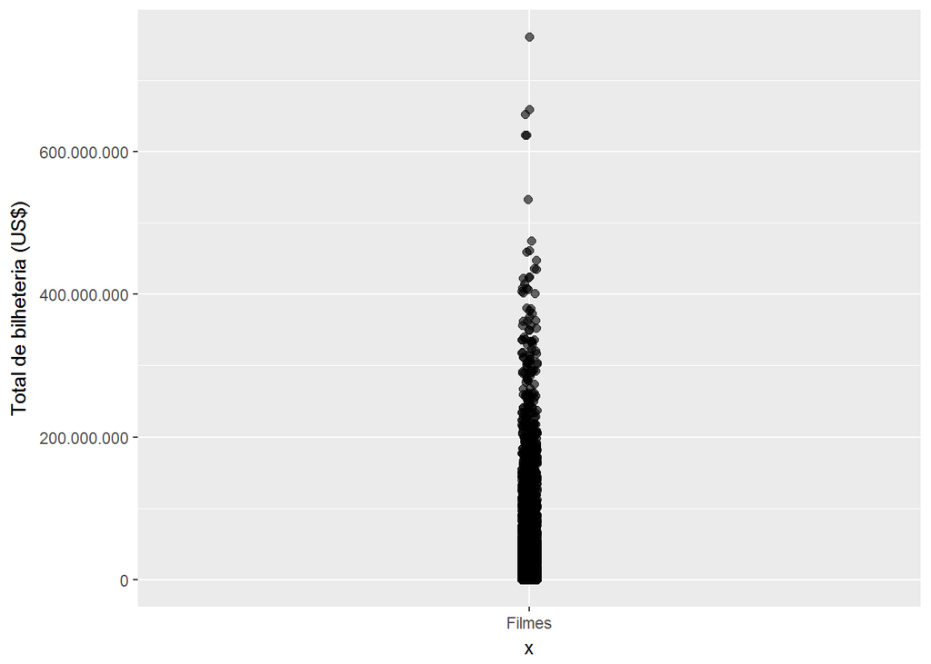

```r
dados_filmes %>%
    ggplot(aes(x = "Filmes", y = gross)) +
    scale_y_continuous(labels = formata_label) +
    labs(y = "Total de bilheteria (US$)") +
    geom_jitter(width = .01, height = 0, size = 2, alpha = .6)
```

### 2.2 budget

```r
summary(dados_filmes$budget)
```

```
##      Min.   1st Qu.    Median      Mean   3rd Qu.      Max.      NA's
## 2.180e+02 6.000e+06 2.000e+07 3.510e+07 4.400e+07 2.128e+09       496
```

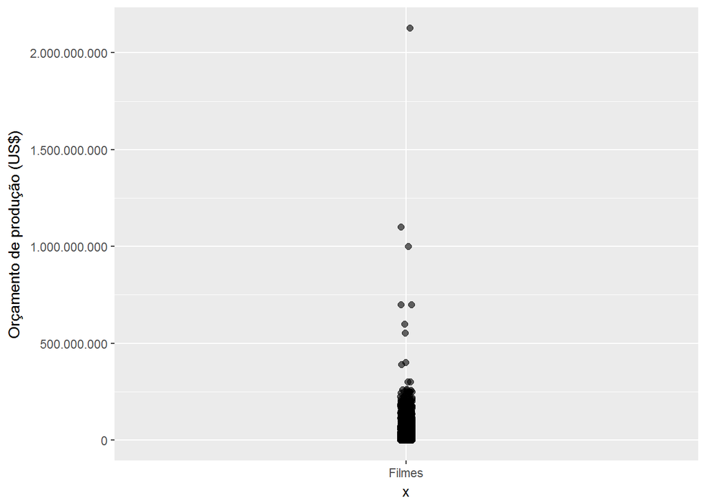

```r
dados_filmes %>%
    ggplot(aes(x = "Filmes", y = budget)) +
    scale_y_continuous(labels = formata_label) +
    labs(y = "Orçamento de produção (US$)") +
    geom_jitter(width = .01, height = 0, size = 2, alpha = .6)
```

### 2.3 duration

```r
summary(dados_filmes$duration)
```

```
##    Min. 1st Qu.  Median    Mean 3rd Qu.    Max.    NA's
##     7.0    93.0   103.0   107.2   118.0   511.0      15
```

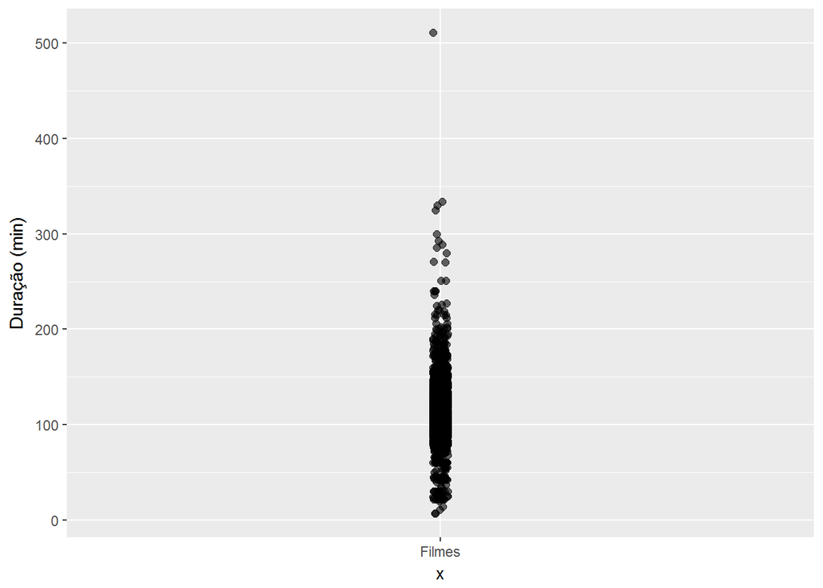

```r
dados_filmes %>%
    ggplot(aes(x = "Filmes", y = duration)) +
    labs(y = "Duração (min)") +
    geom_jitter(width = .01, height = 0, size = 2, alpha = .6)
```

### 2.4 imdb_score

```r
summary(dados_filmes$imdb_score)
```

```
##    Min. 1st Qu.  Median    Mean 3rd Qu.    Max.
##   1.600   5.800   6.600   6.442   7.200   9.500
```

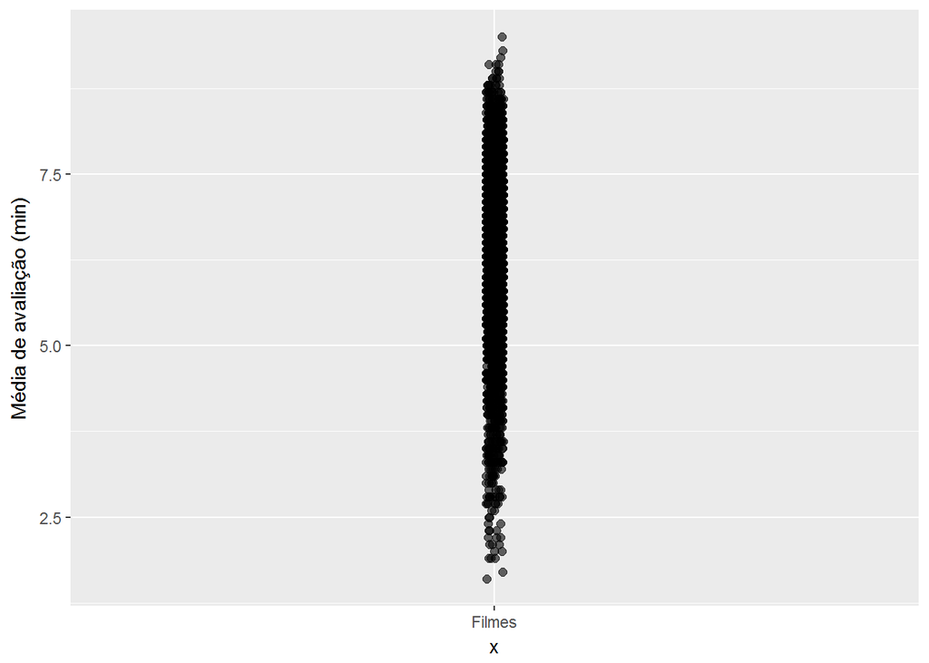

```r
dados_filmes %>%
    ggplot(aes(x = "Filmes", y = imdb_score)) +
    labs(y = "Média de avaliação (min)") +
    geom_jitter(width = .01, height = 0, size = 2, alpha = .6)
```

### 2.5 movie_facebook_likes

```r
summary(dados_filmes$movie_facebook_likes)
```

```
##    Min. 1st Qu.  Median    Mean 3rd Qu.    Max.
##       0       0     166    7526    3000  349000
```

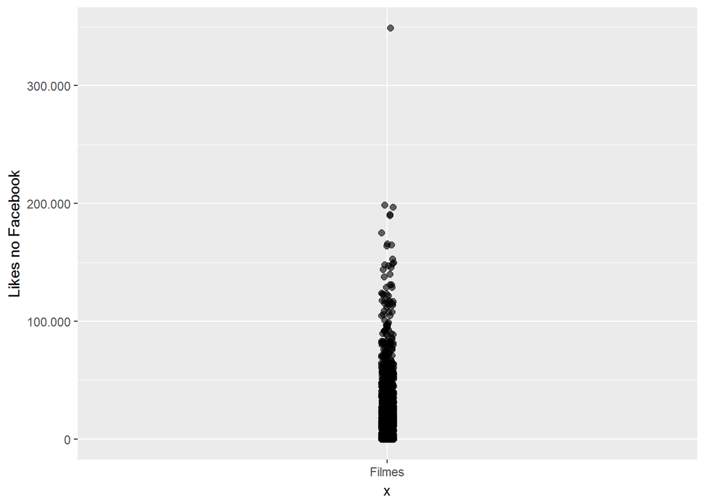

```r
dados_filmes %>%
    ggplot(aes(x = "Filmes", y = movie_facebook_likes)) +
    scale_y_continuous(labels = formata_label) +
    labs(y = "Likes no Facebook") +
    geom_jitter(width = .01, height = 0, size = 2, alpha = .6)
```

## 3. Tratamento de Dados

Analisando as informações proveniente do Kaggle, resolvemos delimitar nosso escopo apenas para filmes que foram produzidos nos EUA. Além disso, observamos algumas inconsistências existentes nos dados que precisam ser tratadas.

A seguir está descrito as inconsistências encontradas no dataset:

- alguns valores estavam faltando para as variáveis gross e budget.
- existiam observações duplicadas na base de dados, ou seja, alguns filmes repetidos.

```r
filmes_usa = dados_filmes %>%
  filter(country == "USA") %>%
  filter(!duplicated(movie_title)) %>%
  select(gross, budget, duration, imdb_score, movie_facebook_likes, movie_title)

filmes_usa = filmes_usa %>%
  filter(complete.cases(filmes_usa))
```

## 4. Critérios de Escolha para o Número de Grupos

Para escolher a quantidade de grupos utilizamos a) o dendrograma b) Dissimilaridade na junção.

### 4.1 Dendrograma

A altura no dendrograma em cada passo significa a dissimilaridade entre os pontos ou grupos juntados naquele passo.

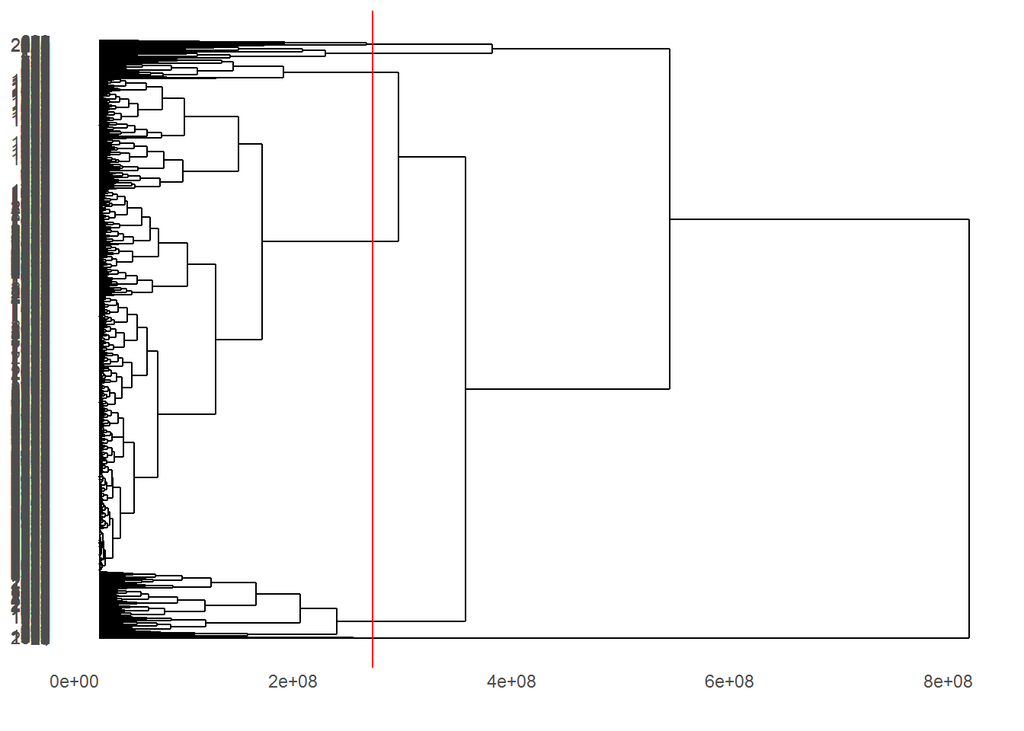

```r
agrupamento_h = filmes_usa %>%
  select(gross, budget, duration, imdb_score, movie_facebook_likes)%>%
  dist(method = "euclidean") %>%
  hclust(method = "complete")

ggdendrogram(agrupamento_h, rotate = T, size = 2) +
    geom_hline(yintercept =250000000, colour = "red")
```

Como pode ser observado no dendrograma acima, levando em consideração as cinco variáveis númericas mais o nome do filme apenas como forma de identificação, foram escolhidos 6 grupos. Poderíamos ter traçado a linha em uma altura mais baixa de forma a agrupar mais, porém optamos por manter o número de grupos mais baixo para uma melhor compreensão acerca dos mesmos. Utilizamos o método “complete” uma vez que tende a produzir grupos mais compactos.

### 4.2 Dissimilaridade da Junção

Na medida que vamos aglomerando, as dissimilaridades nas junções tendem a ir aumentando caso haja estrutura de grupos. Dessa forma, percebemos que uma maior dissimilaridade é apresentada entre as junções 1 e 6 (de trás para frente). Levando em consideração também o dendrograma, podemos considerar que o número ideal de grupos para ser utilizado na análise é 6 (seis).

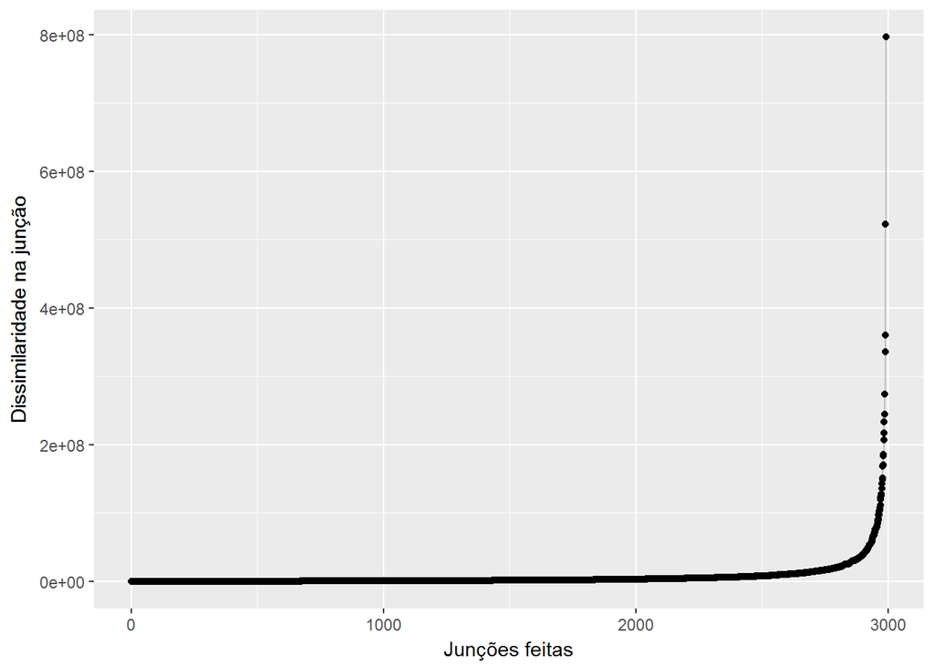

```r
data.frame(k = 1:NROW(agrupamento_h$height),
           height = agrupamento_h$height) %>%
    ggplot(aes(x = k, y = height)) +
    geom_line(colour = "grey") +
    geom_point() +
    labs(x = "Junções feitas", y = "Dissimilaridade na junção")
```

## 5. Avaliação do Agrupamento

### 5.1 Silhoueta

A silhueta nos permite avaliar o quão cada ponto ou grupo está perto de outros pontos e grupos vizinhos, ou seja, o quão bem os dados foram agrupados. Quando observarmos a silhueta para os grupos encontrados, percebemos que foram razoavelmente bem, exceto pelo último e penúltimo grupo com alguns pontos mal agrupados.

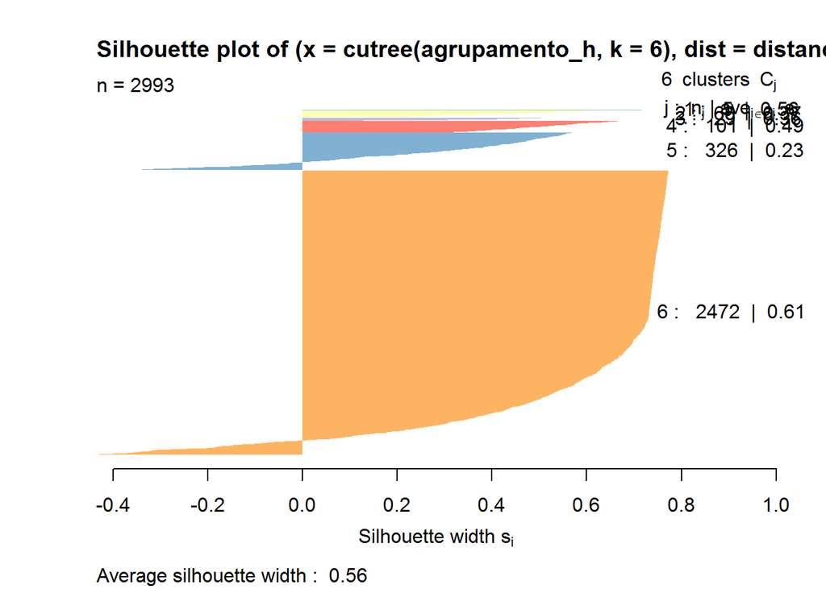

```r
distancias = filmes_usa %>%
    select(gross, budget, duration, imdb_score, movie_facebook_likes) %>%
    dist(method = "euclidean")

cores = RColorBrewer::brewer.pal(6, "Set3")
plot(cluster::silhouette(cutree(agrupamento_h, k = 6), distancias), col = cores, border = NA)
```

### 5.2 Distinção dos Grupos

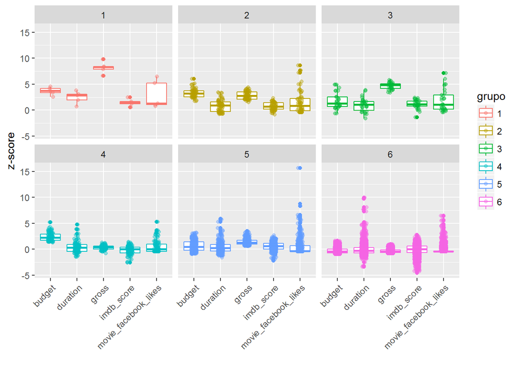

```r
atribuicoes = tibble(k = 1:6) %>%
    group_by(k) %>%
    do(cbind(filmes_usa, grupo = as.character(cutree(agrupamento_h, .$k))))

atribuicoes_long = atribuicoes %>%
    mutate(gross = scale(gross),
           budget = scale(budget),
           duration = scale(duration),
           imdb_score = scale(imdb_score),
           movie_facebook_likes= scale(movie_facebook_likes)) %>%
    gather(key = "variavel", value = "valor",  -movie_title, -grupo, -k)

atribuicoes_long %>%
  filter(k == 6) %>%
  ggplot(aes(x = variavel,
               y = valor,
               colour = grupo)) +
  geom_boxplot() +
  geom_point(alpha = .4, position = position_jitter(width = .1)) +
  facet_wrap(~ grupo) +
  labs(x = "", y = "z-score") +
  theme(axis.text.x = element_text(angle = 45, hjust = 1))
```

O gráfico apresentado possibilita enxergar os aspectos principais que caracterizam cada grupo, ou seja, podemos ver quais são as variáveis que se destacam. Além disso, é possível perceber que todos os grupos são distintos, no entanto, alguns se parecem um pouco, por exemplo os grupos 4, 5 e 6. No próximo tópico, iremos discutir mais sobre as diferenças e as semelhanças existentes entre eles.

## 6. Análise dos Grupos e Conclusão

Para identificar características, diferenças e semelhanças entre os grupos, utilizamos o seguinte gráfico que nos permite obter uma visão geral sobre o agrupamento realizado.

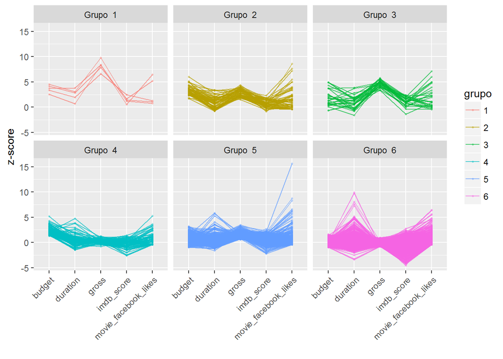

```r
atribuicoes_long %>%
    filter(k == 6) %>%
    ggplot(aes(x = variavel, y = valor, group = movie_title, colour = grupo)) +
    geom_point(alpha = .3, size = .5) +
    geom_line(alpha = .7) +
    facet_wrap(~ paste("Grupo ", grupo)) +
    labs(x = "", y = "z-score") +
    theme(axis.text.x = element_text(angle = 45, hjust = 1))
```

### 6.2 Diferenças, Semelhanças e conclusões

Podemos observar a semelhança existente entre os grupos 2 e 3, as linhas são muito parecidas, no entanto, possuem intensidades diferentes, a mesma semelhança se aplica para os grupos 4, 5 e 6.

Contudo, se pudéssemos reagrupar esses dados em apenas dois grupos, poderíamos juntar os grupos 1, 2, 3 em um dos grupos (devido a semelhança) e os grupos 4, 5, 6 em outro grupo (devido a semelhança). Ambos os dois grupos criados iriam diferir consideravelmente entre eles.